# Sale Price for Detached Homes in the GTA

I. N 7184

December 4, 2020

## I. Data Wrangling

##### a) Set the seed of your randomization to be your student number. Randomly select a sample of 150 cases. Report the IDs of the sample selected. Use your sample data, for the following sections.

IDs reported at bottom under Appendix for visual aesthetic reasons.

##### b) Create a new variable with the name ‘lotsize’ by multiplying lotwidth by lotlength. Use this new variable to replace lotwidth and lotlength.

##### c) Clean the data by removing at most eleven cases and one predictor. Briefly explain your choices. Then use this updated data for the successive parts of this assignment.

I want to remove maxsqfoot because many of its values are missing data, which would give us insufficient/inaccurate results. In terms of cases, I want to remove the two cases missing values for lotsize and the 7 missing values for parking as seen in the skim reading below.

```r
skim(data_IN)
```

Data summary

| Name | data_IN |
| --- | --- |
| Number of rows | 150 |
| Number of columns | 11 |
| _______________________ |  |
| Column type frequency: |  |
| numeric | 11 |
| ________________________ |  |
| Group variables | None |

**Variable type: numeric**

| skim_variable | n_missing | complete_rate | mean | sd | p0 | p25 | p50 | p75 | p100 | hist |
| --- | --- | --- | --- | --- | --- | --- | --- | --- | --- | --- |
| ID | 0 | 1.00 | 1.039e+02 | 5.922e+01 | 1.00 | 5.625e+01 | 1.025e+02 | 154.8 | 229.0 | ▇▇▇▇▃ |
| sale | 0 | 1.00 | 1.806e+06 | 9.882e+05 | 672000.00 | 1.132e+06 | 1.418e+06 | 2193000.0 | 5100000.0 | ▇▅▁▁▁ |
| list | 0 | 1.00 | 1.811e+06 | 1.074e+06 | 649000.00 | 1.050e+06 | 1.464e+06 | 2197250.0 | 5499000.0 | ▇▃▁▁▁ |
| bedroom | 0 | 1.00 | 3.650e+00 | 1.080e+00 | 1.00 | 3.000e+00 | 4.000e+00 | 4.0 | 7.0 | ▂▇▇▂▂ |
| bathroom | 0 | 1.00 | 3.310e+00 | 1.220e+00 | 1.00 | 2.000e+00 | 3.000e+00 | 4.0 | 8.0 | ▆▅▇▁▁ |
| parking | 7 | 0.95 | 3.220e+00 | 2.220e+00 | 0.00 | 2.000e+00 | 2.000e+00 | 4.5 | 10.0 | ▇▃▃▁▁ |
| maxsqfoot | 92 | 0.39 | 2.948e+03 | 1.127e+03 | 1500.00 | 2.000e+03 | 3.000e+03 | 3500.0 | 5000.0 | ▆▃▇▁▃ |
| taxes | 1 | 0.99 | 7.182e+03 | 4.049e+03 | 4.38 | 4.623e+03 | 6.083e+03 | 8622.0 | 23592.0 | ▅▇▂▁▁ |
| lotwidth | 2 | 0.99 | 4.166e+01 | 2.976e+01 | 12.43 | 2.288e+01 | 3.199e+01 | 50.0 | 217.0 | ▇▁▁▁▁ |
| lotlength | 2 | 0.99 | 1.221e+02 | 4.472e+01 | 9.76 | 1.020e+02 | 1.200e+02 | 133.5 | 353.8 | ▁▇▂▁▁ |
| location | 0 | 1.00 | 3.700e-01 | 4.900e-01 | 0.00 | 0.000e+00 | 0.000e+00 | 1.0 | 1.0 | ▇▁▁▁▅ |

```r
data_IN <- select(data_IN, -c(maxsqfoot)) # removing maxsqfoot
attach(data_IN) # column names are not changed after this point
rows <- cbind(ID, sale, list, bedroom, bathroom, parking, taxes, lotwidth, lotlength,
              location)
data_IN <- na.omit(rows) # removing NA values
data_IN <- data.frame(data_IN)
```

## II. Exploratory Data Analysis

##### a) Classify each variable included in this assignment as categorical or discrete or continuous.

From the graphs below, we can tell that location is the only categorical variable in our dataset.

The ID, bedroom, bathroom, and parking seem to be discrete since we can see a somewhat grid-like or bar-like pattern in the scatterplots below.

##### b) Produce the pairwise correlations and scatterplot matrix for all pairs of quantitative variables in the data. Describe how each quantitative predictor for sale price rank, in terms their correlation coefficient, from highest to lowest.

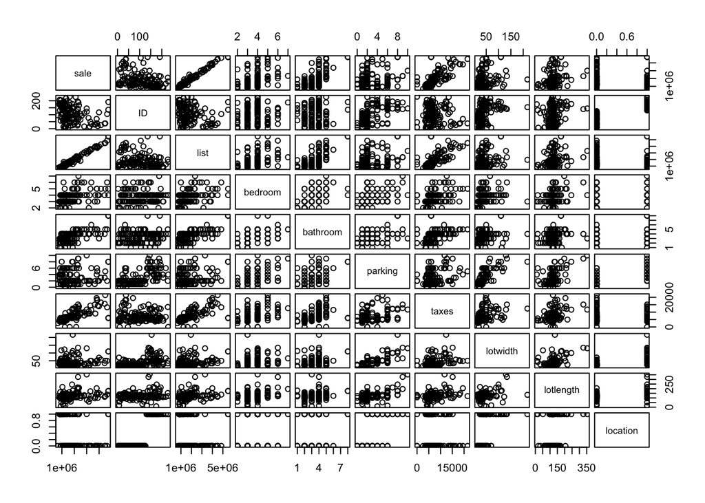

```
##              sale      ID    list bedroom bathroom parking   taxes lotwidth
## sale       1.0000 -0.3074  0.9865  0.4548   0.6454  0.1246  0.7528   0.2122
## ID        -0.3074  1.0000 -0.2514  0.0704   0.1474  0.5694 -0.1104   0.4237
## list       0.9865 -0.2514  1.0000  0.4565   0.6716  0.1780  0.7250   0.2466
## bedroom    0.4548  0.0704  0.4565  1.0000   0.5417  0.3853  0.4333   0.2857
## bathroom   0.6454  0.1474  0.6716  0.5417   1.0000  0.3816  0.4918   0.3127
## parking    0.1246  0.5694  0.1780  0.3853   0.3816  1.0000  0.2917   0.7561
## taxes      0.7528 -0.1104  0.7250  0.4333   0.4918  0.2917  1.0000   0.3724
## lotwidth   0.2122  0.4237  0.2466  0.2857   0.3127  0.7561  0.3724   1.0000
## lotlength  0.2778  0.1948  0.3004  0.3061   0.2114  0.4964  0.3951   0.4403
## location  -0.3068  0.8498 -0.2515  0.0670   0.1455  0.7223 -0.0635   0.5762
##           lotlength location
## sale         0.2778  -0.3068
## ID           0.1948   0.8498
## list         0.3004  -0.2515
## bedroom      0.3061   0.0670
## bathroom     0.2114   0.1455
## parking      0.4964   0.7223
## taxes        0.3951  -0.0635
## lotwidth     0.4403   0.5762
## lotlength    1.0000   0.2416
## location     0.2416   1.0000
```

##### c) Based on the scatterplot matrix, for which single predictor of sale price would the assumption of constant variance be strongly violated? Confirm your answer by showing an appropriate plot of the (standardized) residuals.

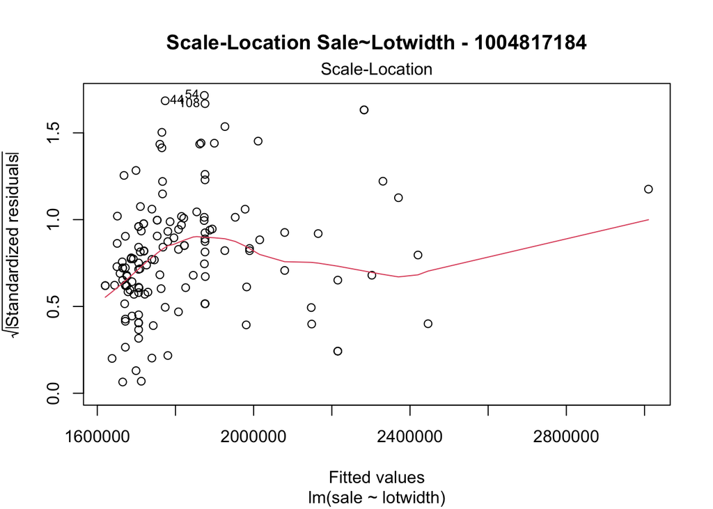